# Assignment 2: Multivariate statistics reproducible

Stijn Hanssen

Oktober 2018

### Clear working space

First step is to make sure that the working space is empty.

```r
# clear all variables
rm(list=ls())
```

### Set path working directory

The directory path is set to the stored datasets.

```r
# set working directory
setwd("C:/Users/stijn/Desktop/Master systems biology/Systems biology year 2/scientific computing/statistic")
```

### Load libraries

Loading the required packages for specific functions.

```r
# pls: used for the multivariate regression methods partial least squares
library(pls)
# caTools: the package inclused basic static functions. for random sampeling
library(caTools)
```

### Import assay data

The first dataset that is imported is the assay data from PubMech [AID624202](https://pubchem.ncbi.nlm.nih.gov/bioassay/624202). The first 6 lines will be skipped for the reason that they don’t contain relevant information for the prediction model. Only the SID and Score collumns will be kept from this dataset.

```r
# Read CSV file, skip first 6 lines
assayData = read.csv(
  file='AID_624202_datatable.csv',
  header=FALSE, skip=6
)
# check the rows and collumns
dim(assayData)
```

```
## [1] 377550     44
```

```r
# inspect the first 5 lines
head(assayData,n=5)
```

```
##   V1     V2      V3       V4 V5
## 1  1 842121 6603008 Inactive  0
## 2  2 842122 6602571 Inactive  0
## 3  3 842123 6602616 Inactive  0
## 4  4 842124  644371 Inactive  0
## 5  5 842125 6603132 Inactive  0
##                                                                           V6
## 1 http://assay.nih.gov/htsws/rest/display/brca1-p1/MLS000076160-01/146270308
## 2 http://assay.nih.gov/htsws/rest/display/brca1-p1/MLS000033655-01/146263970
## 3 http://assay.nih.gov/htsws/rest/display/brca1-p1/MLS000035169-01/146314733
## 4 http://assay.nih.gov/htsws/rest/display/brca1-p1/MLS000075145-01/146418509
## 5 http://assay.nih.gov/htsws/rest/display/brca1-p1/MLS000077240-01/146368731
##   V7       V8 V9 V10 V11 V12 V13   V14   V15    V16      V17     V18 V19
## 1 NA Inactive NA  NA  NA   0        NA    NA     NA       NA      NA   4
## 2 NA Inactive NA  NA  NA   0     -4.45 3.990 0.8935 -17.5515 -3.2454   4
## 3 NA Inactive NA  NA  NA   0        NA    NA     NA       NA      NA   4
## 4 NA Inactive NA  NA  NA   0        NA    NA     NA       NA      NA   4
## 5 NA Inactive NA  NA  NA   0     -4.90 4.095 0.8365 -25.5425  9.5464   4
##       V20      V21 V22 V23 V24 V25     V26 V27 V28 V29 V30     V31 V32 V33
## 1           0.5909  NA  NA  NA  NA  0.0000  NA  NA  NA  NA  0.0000  NA  NA
## 2 0 0 0 0 -13.7929  NA  NA  NA  NA -5.6459  NA  NA  NA  NA -1.4545  NA  NA
## 3          -0.9753  NA  NA  NA  NA -2.4119  NA  NA  NA  NA  3.2689  NA  NA
## 4           1.6001  NA  NA  NA  NA -0.6413  NA  NA  NA  NA -4.9545  NA  NA
## 5 0 0 0 0 -25.1872  NA  NA  NA  NA  0.6014  NA  NA  NA  NA 18.4558  NA  NA
##   V34 V35 V36     V37 V38 V39 V40      V41 V42 V43                 V44
## 1  NA  NA  NA  0.0000  NA  NA  NA   0.5909  NA  NA      QC'd by DPISMR
## 2  NA  NA  NA -2.1328  NA  NA  NA -13.7929  NA  NA QC'd by Asinex Ltd.
## 3  NA  NA  NA -0.6045  NA  NA  NA  -0.9753  NA  NA      QC'd by DPISMR
## 4  NA  NA  NA -0.0041  NA  NA  NA   1.6001  NA  NA      QC'd by DPISMR
## 5  NA  NA  NA  2.1005  NA  NA  NA -25.1872  NA  NA QC'd by Asinex Ltd.
```

```r
# keep the SID and Score column
assayData = assayData[,c("V2","V5")]
# change the column names
colnames(assayData) = c("SID","Score")
dim(assayData)
```

```
## [1] 377550      2
```

```r
head(assayData,n=5)
```

```
##      SID Score
## 1 842121     0
## 2 842122     0
## 3 842123     0
## 4 842124     0
## 5 842125     0
```

### Import descriptors file

In this section will the descriptors file be imported For the development of the discriptor file go to: descriptors.Rmd. The `descriptors.Rmd` uses the downloaded assay data from PubMech [AID624202](https://pubchem.ncbi.nlm.nih.gov/bioassay/624202).

```r
discriptorData = read.csv(
  file='descriptors.csv',
  header=TRUE,row.names = 2
)
dim(discriptorData)
```

```
## [1] 1050  246
```

```r
head(discriptorData,n=5)
```

```
##           X XLogP       MW LipinskiFailures nRotB MLogP nAtomLAC nAtomP
## 124897530 1 1.135 369.1689                0    10  2.89        3      8
## 124897303 2 4.498 249.0954                0     2  3.11        2     18
## 124753561 3 4.554 657.2309                0    11  4.21        0      9
## 124753354 4 8.321 501.1465                1     9  2.89        4     16
## 121286038 5 4.515 637.2247                0    10  4.32        2     24
##           nAtomLC nB nBase nAtom nAromBond naAromAtom  ALogP     ALogp2
## 124897530      10 28     1    50        12         12 0.8444  0.7130114
## 124897303       2 21     0    31        17         16 4.2287 17.8819037
## 124753561       4 52     0    83        23         23 4.7561 22.6204872
## 124753354       5 34     0    60        16         15 4.1324 17.0767298
## 121286038       4 52     0    81        28         27 5.0096 25.0960922
##                AMR nAcid nSmallRings nAromRings nRingBlocks nAromBlocks
## 124897530  99.0052     0           2          2           2           2
## 124897303  75.5003     0           3          3           2           2
```

[output cut: 207 more lines]

```r
# Delete "X" column, which only contains numbers
discriptorData = discriptorData[,-1]
dim(discriptorData)
```

```
## [1] 1050  245
```

```r
head(discriptorData,n=5)
```

```
##           XLogP       MW LipinskiFailures nRotB MLogP nAtomLAC nAtomP
## 124897530 1.135 369.1689                0    10  2.89        3      8
## 124897303 4.498 249.0954                0     2  3.11        2     18
## 124753561 4.554 657.2309                0    11  4.21        0      9
## 124753354 8.321 501.1465                1     9  2.89        4     16
## 121286038 4.515 637.2247                0    10  4.32        2     24
##           nAtomLC nB nBase nAtom nAromBond naAromAtom  ALogP     ALogp2
## 124897530      10 28     1    50        12         12 0.8444  0.7130114
## 124897303       2 21     0    31        17         16 4.2287 17.8819037
## 124753561       4 52     0    83        23         23 4.7561 22.6204872
## 124753354       5 34     0    60        16         15 4.1324 17.0767298
## 121286038       4 52     0    81        28         27 5.0096 25.0960922
##                AMR nAcid nSmallRings nAromRings nRingBlocks nAromBlocks
## 124897530  99.0052     0           2          2           2           2
## 124897303  75.5003     0           3          3           2           2
```

[output cut: 207 more lines]

### Match SID

The SID column from both data sets will be matched, in order to add the score column to the discriptorData. In the variable `data` is the new dataset stored.

```r
# match by SID column
data = assayData[match(rownames(discriptorData),assayData$SID),]
# add the score column to the discriptordata
data = cbind(discriptorData,data$Score)
dim(data)
```

```
## [1] 1050  246
```

```r
head(data,n=5)
```

```
##           XLogP       MW LipinskiFailures nRotB MLogP nAtomLAC nAtomP
## 124897530 1.135 369.1689                0    10  2.89        3      8
## 124897303 4.498 249.0954                0     2  3.11        2     18
## 124753561 4.554 657.2309                0    11  4.21        0      9
## 124753354 8.321 501.1465                1     9  2.89        4     16
## 121286038 4.515 637.2247                0    10  4.32        2     24
##           nAtomLC nB nBase nAtom nAromBond naAromAtom  ALogP     ALogp2
## 124897530      10 28     1    50        12         12 0.8444  0.7130114
## 124897303       2 21     0    31        17         16 4.2287 17.8819037
## 124753561       4 52     0    83        23         23 4.7561 22.6204872
## 124753354       5 34     0    60        16         15 4.1324 17.0767298
## 121286038       4 52     0    81        28         27 5.0096 25.0960922
##                AMR nAcid nSmallRings nAromRings nRingBlocks nAromBlocks
## 124897530  99.0052     0           2          2           2           2
## 124897303  75.5003     0           3          3           2           2
```

[output cut: 207 more lines]

### Data cleaning (remove NA and 0 collumns)

During data inspection, it came to the attation that there are columns with only NA values and columns with no variance. These column wont have any added value to the prediction model and thus will be removed.

```r
# check for columns with NA and remove them
data = data[, colSums(is.na(data)) != nrow(data)]
dim(data)
```

```
## [1] 1050  216
```

```r
head(data,n=5)
```

```
##           XLogP       MW LipinskiFailures nRotB MLogP nAtomLAC nAtomP
## 124897530 1.135 369.1689                0    10  2.89        3      8
## 124897303 4.498 249.0954                0     2  3.11        2     18
## 124753561 4.554 657.2309                0    11  4.21        0      9
## 124753354 8.321 501.1465                1     9  2.89        4     16
## 121286038 4.515 637.2247                0    10  4.32        2     24
##           nAtomLC nB nBase nAtom nAromBond naAromAtom  ALogP     ALogp2
## 124897530      10 28     1    50        12         12 0.8444  0.7130114
## 124897303       2 21     0    31        17         16 4.2287 17.8819037
## 124753561       4 52     0    83        23         23 4.7561 22.6204872
## 124753354       5 34     0    60        16         15 4.1324 17.0767298
## 121286038       4 52     0    81        28         27 5.0096 25.0960922
##                AMR nAcid nSmallRings nAromRings nRingBlocks nAromBlocks
## 124897530  99.0052     0           2          2           2           2
## 124897303  75.5003     0           3          3           2           2
```

[output cut: 189 more lines]

```r
# filter out the columns with no variance
data = Filter(var,data)
dim(data)
```

```
## [1] 1050  169
```

```r
head(data,n=5)
```

```
##           XLogP       MW LipinskiFailures nRotB MLogP nAtomLAC nAtomP
## 124897530 1.135 369.1689                0    10  2.89        3      8
## 124897303 4.498 249.0954                0     2  3.11        2     18
## 124753561 4.554 657.2309                0    11  4.21        0      9
## 124753354 8.321 501.1465                1     9  2.89        4     16
## 121286038 4.515 637.2247                0    10  4.32        2     24
##           nAtomLC nB nBase nAtom nAromBond naAromAtom nAcid nSmallRings
## 124897530      10 28     1    50        12         12     0           2
## 124897303       2 21     0    31        17         16     0           3
## 124753561       4 52     0    83        23         23     0           6
## 124753354       5 34     0    60        16         15     1           3
## 121286038       4 52     0    81        28         27     0           7
##           nAromRings nRingBlocks nAromBlocks nRings3 nRings4 nRings5
## 124897530          2           2           2       0       0       0
## 124897303          3           2           2       0       0       0
```

[output cut: 141 more lines]

### Split data into train and test data

The `caTools` library is used to randomly generate train and test data. 80 percent of the data will be used as training data (`train`) while the other 20 precent will be used as test data (`test`). Further will the score column stored into a variable.

```r
# set the seed for the reason that always the same sequence will be generated
set.seed(101)
# random sample of 80 percent
sample = sample.split(data, SplitRatio = .80)
# subset the 80 percent data
train = subset(data, sample == TRUE)
# store the score in a variable
train_y = train$`data$Score`
# subset the 20 percent data
test  = subset(data, sample == FALSE)
test_y = test$`data$Score`
```

### Partial Least Squares (pls) model

The `pls` library is used for the development of the prediction model (`pls_model_CV`). pls is being used for the reason that there are relativily many predictor variables and relativly a few samples. Hardly any difference is seen in the model by adding cross validation.

```r
# fitting the PLS model. score agianst all other variables. the model is fit with 10 components
pls_model <- plsr(`data$Score` ~ .,ncomp = 10, data = train)
# overview of the fit and validation results
summary(pls_model)
```

```
## Data:    X dimension: 841 168
##  Y dimension: 841 1
## Fit method: kernelpls
## Number of components considered: 10
## TRAINING: % variance explained
##               1 comps    2 comps  3 comps  4 comps  5 comps  6 comps
## X           9.997e+01  1.000e+02  100.000  100.000  100.000  100.000
## data$Score  1.147e-04  2.396e-03    4.619    5.215    6.445    7.188
##             7 comps  8 comps  9 comps  10 comps
## X           100.000  100.000  100.000   100.000
## data$Score    7.258    7.342    7.859     7.859
```

```r
# cross validation divided into segments of 10
pls_model_CV <- plsr(`data$Score` ~ .,ncomp = 10, data = train,validation = "CV")
summary(pls_model_CV)
```

```
## Data:    X dimension: 841 168
##  Y dimension: 841 1
## Fit method: kernelpls
## Number of components considered: 10
##
## VALIDATION: RMSEP
## Cross-validated using 10 random segments.
##        (Intercept)  1 comps  2 comps  3 comps  4 comps  5 comps  6 comps
## CV           23.63    23.68     23.7    23.16    23.13    23.06    23.14
## adjCV        23.63    23.67     23.7    23.16    23.12    23.05    23.11
##        7 comps  8 comps  9 comps  10 comps
## CV       23.02    23.07    23.08     23.08
## adjCV    23.01    23.06    23.01     23.02
##
## TRAINING: % variance explained
##               1 comps    2 comps  3 comps  4 comps  5 comps  6 comps
## X           9.997e+01  1.000e+02  100.000  100.000  100.000  100.000
## data$Score  1.147e-04  2.396e-03    4.619    5.215    6.445    7.188
##             7 comps  8 comps  9 comps  10 comps
## X           100.000  100.000  100.000   100.000
## data$Score    7.258    7.342    7.859     7.859
```

### Root Mean Squared Error of Prediction (RMSEP) plot

RMSE measures how spread out the residuals are. The summary above showed two cross validation estimates, the ordinary CV and the adjCV which is a bias-correctd CV estimate. After inspecting this plot it becomes clear that the third component is the best to choose for future functions.

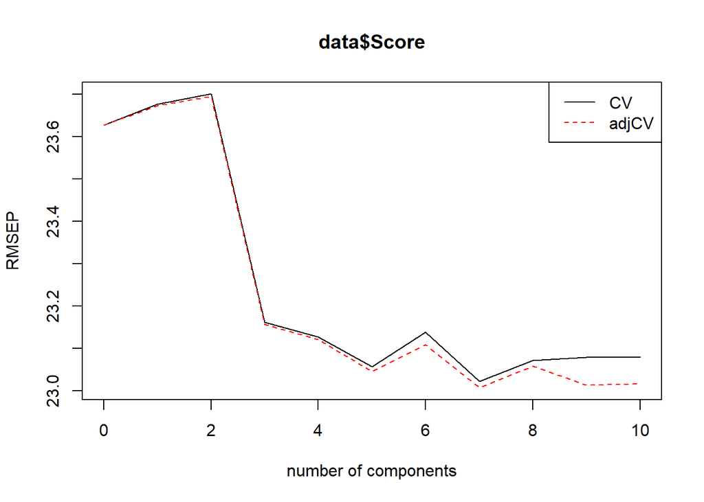

```r
# plots the estimated RMSEP as a function of the number of components. legendpos indicated the legend position
plot(RMSEP(pls_model_CV), legendpos="topright")
```

### Plot the prediction by using the third component on the training set

The plot shows the cross validated prediction by use of the third component.

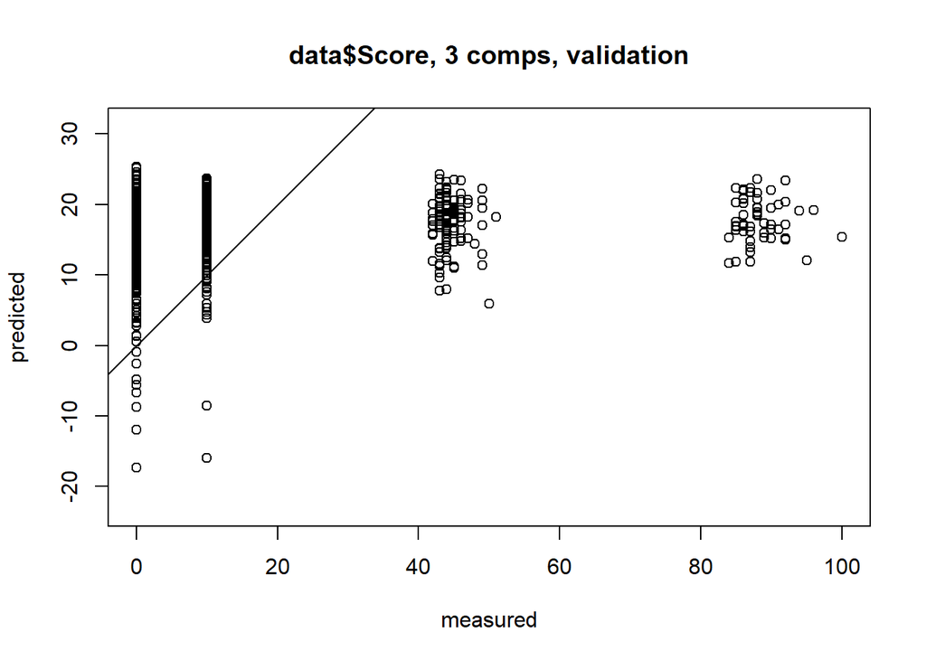

```r
# use the plot function for prediction, number of component was selected from the above figure, aspect ratio on 1 to produce a plot where distance between points are accurate, line arguement for regression line
plot(pls_model_CV, ncomp = 3, asp = 1, line = TRUE)
```

### Pairwise plot

The score values of the first three components are shown. These plots are used to see patterns, groups and/or outliers in the data. Behind each component are relative amount of variance explained by each component, these are explict extracted by `explvar` function. Explained variance: proportion mathemaical model acount for variation of the dataset.

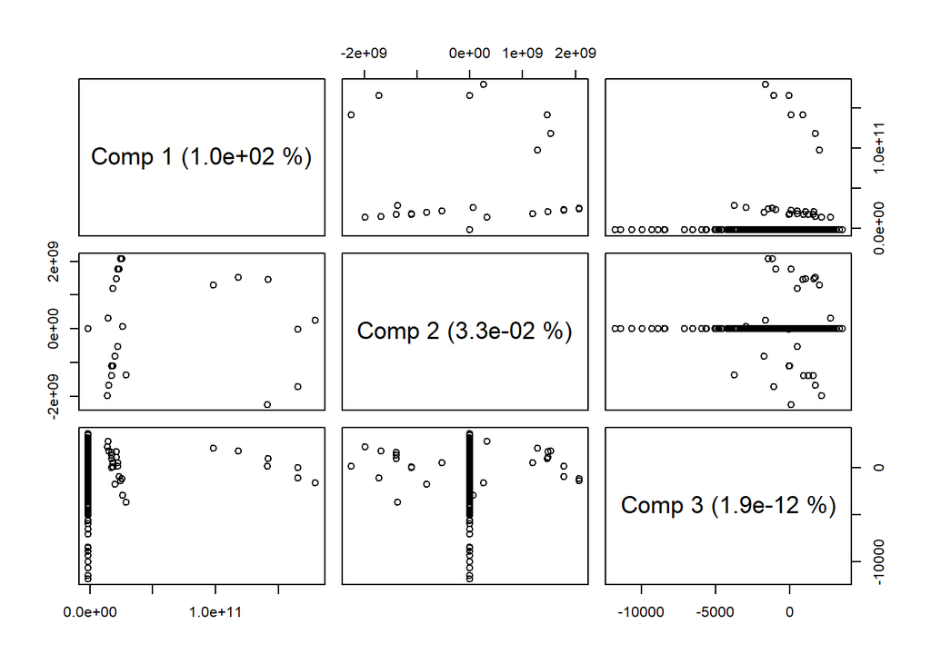

```r
plot(pls_model_CV, plottype = "scores", comps = 1:3)
```

```r
# extract amount of variance explianed for each component in the model
explvar(pls_model_CV)
```

```
##       Comp 1       Comp 2       Comp 3       Comp 4       Comp 5
## 9.996743e+01 3.257332e-02 1.944892e-12 1.263132e-13 3.219183e-14
##       Comp 6       Comp 7       Comp 8       Comp 9      Comp 10
## 2.954816e-15 6.884545e-15 5.627196e-15 8.156122e-14 1.566932e-13
```

### Predict on test set

The pls fitted model is being used to predict the values of the test data and stored into a new variable (`prediction_and_true_values_testset`).

```r
# store the prediction  as a data frame
prediction = as.data.frame(predict(pls_model_CV, ncomp = 3, newdata = test))
# combine the predicted values with the true values
prediction_and_true_values_testset = cbind(prediction,test_y)
# show the first 20 rows
head(prediction_and_true_values_testset,n=20)
```

```
##           data$Score.3 comps test_y
## 121284703          10.711046     10
## 103163060          13.213873     43
## 103075408          13.213873     92
## 103073584          15.806131      0
## 99359820           12.804118     45
## 99357284           -2.525998      0
## 93577400           19.298794     10
## 89854427           21.124577     10
## 89854409           10.655194     10
## 89852947           20.618815     10
## 89852445           20.404825      0
## 89852402            6.720843      0
## 87349736            9.625844     10
## 87335450           23.261205     10
## 85271492           16.972813      0
## 85270247           20.251590     10
## 85199553           18.066638     45
## 85149214           16.196230     44
## 57269011           14.565320     85
## 57265099           14.230812      0
```

### RMSEP test set

The component score seems to be quite close to the cross-validated estimate of the train RMSEP.

```r
RMSEP(pls_model_CV, newdata = test)
```

```
## (Intercept)      1 comps      2 comps      3 comps      4 comps
##       24.69        24.70        24.69        24.56        24.23
##     5 comps      6 comps      7 comps      8 comps      9 comps
##       24.05        23.97        23.96        23.97        23.95
##    10 comps
##       23.95
```

### Test set plot

The plot shows the measured value’s versus the predicted values of the test set. The prediction model is not capable to predict the true measrued values.

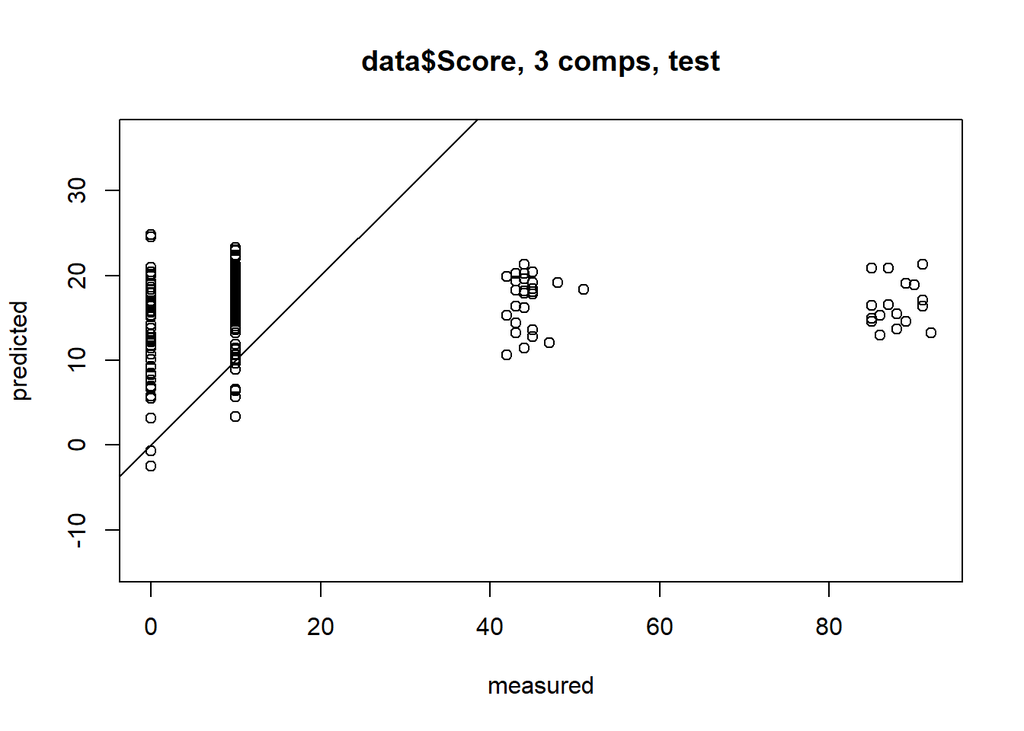

```r
# predplot is used because it plots the prior predictive distribution of the number of successes in the trail
predplot(pls_model_CV, ncomp = 3, newdata = test, asp = 1, line = TRUE)
```